# Data Assignment 3 (4 Points)

MGOC15 - Introductory Business Data Analytics

**Topics Tested:** Data Cleaning, Concatenation, Imputation, Field Inconsistencies.  
**Submission Format** Please submit your assignment as *MGOC15 Assignment 3 - Last Name, First Name.ipynb* You may work in teams of two (or individually) but you must each submit your assignment separately and also mention your partner's name so that your work does not seem plagiarized.

### Florence AirBnB Bookings

The (government of) beautiful city of Florence in Italy is tired of how AirBnBs have taken over the city. However, they are also keenly aware of how tourism is their number one source of revenue. Trying to balance these two needs, the city wants to understand what factors motivate people to book AirBnBs.

To answer this question, you have procured two datasets "AirBnB_Centro.csv" and "AirBnB_Rest.csv, which contain a number of columns. Please familiarize yourself with each column before you proceed with the analysis. Note that the two files contain the same set of columns.

**We will use BookingsPerMonth** as the outcome variable, which denotes the average number of bookings a property has received in a given month (Since this denotes the total number of bookings divided by the time period, it is likely to be a fraction).

**CommissionsPerMonth** can also be viewed as an outcome variable.

**Note:** Before answering the questions, please go to to the Jupyter's menu and execute "Kernel", "Restart & Run all." This will ensure that the notebook and modules are appropriately loaded. Qualitative questions can be answered either as comments or Jupyter markups in the appropriate cells.

*This assignment is worth 4 points*

### Loading Python modules

We start by first importing packages and modules needed for our analysis

```python
import pandas as pd               # for data manipulation
import numpy as np                # for stats and numerical analysis
import matplotlib.pyplot as plt   # for plotting and data visualization
```

## Extra Material

(Please read before proceeding)

Before proceeding with this assignment, note that we can delete entries from specific columns (instead of from the whole dataframe). So far, we've been using df.dropna(axis=0) to delete all rows containing even one missing entry. What if we want to delete only those rows that contain missing entries in columns "X" or "Y"? Then, you can use

*df.dropna(axis=0,subset=['X', 'Y'])*

If you have any questions on this, you can ask your instructor. You won't be tested on this extra material for your midterm (but you will for your final exam)

### Question 1: Joining and Saving the datasets [1 point]

As mentioned above, the AirBnB data has been provided in two datasets with the more popular Centro Storico (Historic Centre) listings in their own dataset **AirBnB_Centro.csv** and the remaining in **AirBnB_Rest.csv**. Correct this problem by joining the two datasets and **saving the result into a new CSV file**.

```python
dfCentro = pd.read_csv('AirBnB_Centro.csv')
dfRest = pd.read_csv('AirBnB_Rest.csv')
dfCon = pd.concat([dfCentro, dfRest])
dfCon.to_csv("updated.csv")
dfUpdated = pd.read_csv("updated.csv")
dfUpdated.head()
```

|  | Unnamed: 0 | HostResponseTime | HostResponseRate | HostAcceptRate | Superhost | HostListings | nbhood | Latitude | Longitude | RoomType | ... | AvgRating | RatingAccuracy | RatingClean | RatingCheckIn | RatingCommunication | RatingLocation | RatingValue | StantBk | BookingsPerMonth | CommissionsPerMonth |
| --- | --- | --- | --- | --- | --- | --- | --- | --- | --- | --- | --- | --- | --- | --- | --- | --- | --- | --- | --- | --- | --- |
| 0 | 0 | within an hour | 1.0 | 1.00 | f | 32 | Centro Storico | 43.77709 | 11.25216 | Private room | ... | 4.65 | 4.73 | 4.87 | 4.85 | 4.91 | 4.90 | 4.71 | t | 1.19 | 34.8075 |
| 1 | 1 | within an hour | 1.0 | 1.00 | f | 5 | Centro Storico | 43.76268 | 11.24149 | Hotel room | ... | 4.84 | 4.82 | 4.87 | 4.88 | 4.92 | 4.71 | 4.82 | t | 4.58 | 144.2700 |
| 2 | 2 | within an hour | 1.0 | 0.83 | f | 10 | Centro Storico | 43.77525 | 11.25258 | Private room | ... | 4.47 | 4.60 | 4.65 | 4.79 | 4.72 | 4.88 | 4.49 | f | 0.65 | 14.6250 |
| 3 | 3 | within an hour | 1.0 | 0.83 | f | 10 | Centro Storico | 43.77525 | 11.25258 | Private room | ... | 4.08 | 3.83 | 4.33 | 4.58 | 4.42 | 5.00 | 4.17 | f | 0.56 | 15.1200 |
| 4 | 4 | within an hour | 1.0 | 1.00 | f | 189 | Centro Storico | 43.76944 | 11.26331 | Entire home/apt | ... | 3.00 | 4.00 | 4.00 | 4.50 | 3.50 | 4.50 | 4.00 | t | 0.03 | 1.4445 |

5 rows × 32 columns

It goes without saying that all the subsequent analyses must be on the joined file.

### Question 2: Modifying the DataFrame and Field Inconsistencies [1 point]

As a first step, we will make cosmetic changes to the joined dataframe to make sure that it looks professional.

a) Rename the columns "nbhood" and "StantBk" so that their names sound more professional.  
--- *nbhood*: Neighbourhood in which the property is located.  
--- *StantBk*: Whether or not the host allows *instant booking* for this property.

b) Some AirBnB hosts have marked their homes as having 1.5 bathrooms. Anyone who has hunted for an apartment/house in North America knows that this is standard practice for bathrooms that do not contain a shower. However, the Florence government has a different view on this. Any house with 1.5 bathrooms actually contains two distinct bathrooms and so this field cannot have any fractional entries.

Correct this field inconsistency before proceeding (any row with 1.5 bathrooms needs to be converted to 2).

```python
#Answer 2a
col_dict = {'nbhood': 'Neighbourhood', 'StantBk': 'InstantBookingAllowed'}
dfUpdated = dfUpdated.rename(columns = col_dict)
dfUpdated.head(5)
```

|  | Unnamed: 0 | HostResponseTime | HostResponseRate | HostAcceptRate | Superhost | HostListings | Neighbourhood | Latitude | Longitude | RoomType | ... | AvgRating | RatingAccuracy | RatingClean | RatingCheckIn | RatingCommunication | RatingLocation | RatingValue | InstantBookingAllowed | BookingsPerMonth | CommissionsPerMonth |
| --- | --- | --- | --- | --- | --- | --- | --- | --- | --- | --- | --- | --- | --- | --- | --- | --- | --- | --- | --- | --- | --- |
| 0 | 0 | within an hour | 1.0 | 1.00 | f | 32 | Centro Storico | 43.77709 | 11.25216 | Private room | ... | 4.65 | 4.73 | 4.87 | 4.85 | 4.91 | 4.90 | 4.71 | t | 1.19 | 34.8075 |
| 1 | 1 | within an hour | 1.0 | 1.00 | f | 5 | Centro Storico | 43.76268 | 11.24149 | Hotel room | ... | 4.84 | 4.82 | 4.87 | 4.88 | 4.92 | 4.71 | 4.82 | t | 4.58 | 144.2700 |
| 2 | 2 | within an hour | 1.0 | 0.83 | f | 10 | Centro Storico | 43.77525 | 11.25258 | Private room | ... | 4.47 | 4.60 | 4.65 | 4.79 | 4.72 | 4.88 | 4.49 | f | 0.65 | 14.6250 |
| 3 | 3 | within an hour | 1.0 | 0.83 | f | 10 | Centro Storico | 43.77525 | 11.25258 | Private room | ... | 4.08 | 3.83 | 4.33 | 4.58 | 4.42 | 5.00 | 4.17 | f | 0.56 | 15.1200 |
| 4 | 4 | within an hour | 1.0 | 1.00 | f | 189 | Centro Storico | 43.76944 | 11.26331 | Entire home/apt | ... | 3.00 | 4.00 | 4.00 | 4.50 | 3.50 | 4.50 | 4.00 | t | 0.03 | 1.4445 |

5 rows × 32 columns

```python
#Answer 2b
dfUpdated['Bathrooms'] = np.round(dfUpdated['Bathrooms'])
```

### Question 3: Missing Entries: Deletion and Imputation [1 point]

Unfortunately, the dataset is missing several entries over multiple columns, so we will carefully apply deletion in some parts and imputation in others. First of all, we can assume that all missing entries are due to an Excel error by the statistician handling the dataset, who is amazing with Python but not so much with Excel.

Please deal with missing values in the following columns only:

---Bedrooms  
---Price  
---MinNights  
---BookingsPerMonth  
---CommissionsPerMonth  
---AvgRating

In class, we've been told that it's okay to delete as long as you are deleting fewer than 5\% of values. In general, this is an acceptable approach. However, for this problem, your manager at the city has imposed a hard limit: **No deleting more than 100 entries**. So solve this problem accordingly. You may use the method discussed above to delete rows for missing entries corresponding to specific columns only (there's no point in deleting missing entries, when that column is not being used anywhere).

Since the Bedrooms column is missing more than 100 entries, we cannot use deletion. Consider replacing the missing entries with the mean or the median. Which one is more appropriate for this column and why?

```python
cols = ['Bedrooms', 'Price', 'MinNights', 'BookingsPerMonth', 'CommissionsPerMonth', 'AvgRating']
dfUpdated[cols].isnull().sum()
```

```
Bedrooms               232
Price                   27
MinNights                0
BookingsPerMonth         0
CommissionsPerMonth      2
AvgRating                0
dtype: int64
```

```python
dfDropCP = dfUpdated.dropna(axis=0, subset=['CommissionsPerMonth', 'Price'])
median = dfUpdated['Bedrooms'].median()
dfFinal = dfDropCP.fillna({'Bedrooms': median})
dfFinal[cols].isnull().sum()
```

```
Bedrooms               0
Price                  0
MinNights              0
BookingsPerMonth       0
CommissionsPerMonth    0
AvgRating              0
dtype: int64
```

### Question 4: Data Discrepancies [1 point]

As you may be aware, AirBnB collects a commission of 15\% of each booking (in other words, if you pay \$50 for each night and you stay for 2 nights, then AirBnB collects a commission of \$15 for this booking). In our dataframe, this is reflected in the **CommissionsPerMonth** column.

However, the government is concerned that AirBnB is underreporting these commissions. Use the data to validate or deny this hypothesis. In particular, our goal is to identify the total dollar amount that is being underreported, e.g., if the actual commissions is \$1000 and AirBnB is only reporting \\$900, then the underreporting (which you need to find) is \$100.

Here is some information that may help you solve this problem:

i) The bookings per month give you the number of customers who have booked a stay at the particular property.  
ii) You can assume that each customer stays for exactly 3 nights.  
iii) The price column gives you the price that the customer pays for a single night.

i), ii), and iii) together with the 15\% commission should help you calculate the platform's actual commissions collected. You can compare this to the reported column **CommissionsPerMonth** column to calculate the underreporting.

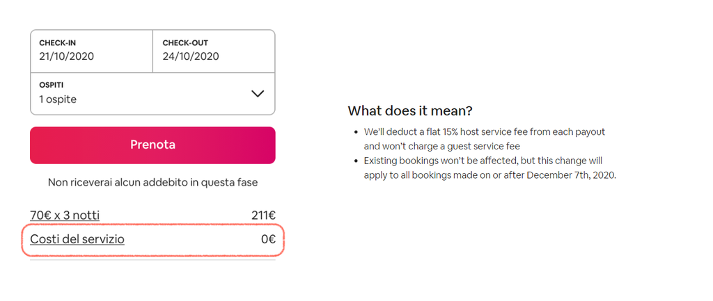

```python
dfFinal['bpm*3*price*15%'] = dfFinal['BookingsPerMonth']*3*dfFinal['Price']*0.15
actual = dfFinal['bpm*3*price*15%'].sum()
```

```python
reported = dfFinal['CommissionsPerMonth'].sum()
```

```python
underreporting = actual - reported
print(underreporting)
```

```
1231.045000000042
```